# NumPy: A look at the past, present, and future of array computation

# Part III - Developing NumPy

# [Scope of NumPy](https://numpy.org/neps/scope.html)

The NumPy execution engine currently targets:

- in-memory, homogenously-typed array data
- cpu-based operations

Specialized hardware (e.g. GPUs), features for scalable computing (e.g. distributed arrays) are currently out of scope

- Supporting libraries that provide these features *is in scope*: **extensibility** and **interoperability**

Important guiding principles:

- **Stability**: Foundational component of the scientific python ecosystem for going-on 15 years
- **Interoperability**
  - NumPy is the standard array data structure within the scientific Python ecosystem
  - What about all the new array libraries?
    - [XArray](http://xarray.pydata.org/en/stable/)
    - [Dask Arrays](https://docs.dask.org/en/latest/array.html)
    - [Jax](https://jax.readthedocs.io/en/latest/)
    - [pydata sparse](https://sparse.pydata.org/en/latest/)
    - [PyTorch](https://pytorch.org/)
    - [TensorFlow](https://www.tensorflow.org/api_docs)

# How is NumPy Developed?

- **Collaboratively** - https://github.com/numpy/numpy/

Commitment to stability means proposed changes must go through extensive design and review:

- [Numpy Enhancement Proposals (NEPs)](https://numpy.org/neps/) - analogous to PEPs, specific to NumPy
  - Community-driven development and consensus among contributors/developers
    - Mailing list
    - PRs/Issues on GitHub
- Steering council for high-level direction

# A case-study: `np.random`

- Changes proposed in [NEP 19](https://numpy.org/neps/nep-0019-rng-policy.html), subsequently approved by the community via discussion on the mailing list and on GitHub.
- Overhaul of `np.random` landed in version 1.17
  - Improve *performance* and *flexibility* without sacrificing stability

```python
# Generate 1,000,000 random numbers the old way
old_rands = np.random.random(int(1e6))
print("Uniform random numbers from legacy np.random.random:\n  {}".format(old_rands))
```

```
Uniform random numbers from legacy np.random.random:
  [0.59644566 0.44341334 0.41266632 ... 0.33702302 0.87330171 0.62672533]
```

```python
# ... and the new way
from numpy.random import default_rng
rg = default_rng()
new_rands = rg.random(int(1e6))
print("Uniform random numbers with new tools:\n  {}".format(new_rands))
```

```
Uniform random numbers with new tools:
  [0.31248523 0.69974081 0.39190157 ... 0.75976854 0.75859921 0.18642345]
```

## Compatibility

There are many, many LOC (both in test suites and in production) that depend on the original `numpy.random`, so both the *interface* and the *results* must remain unchanged

- **Upside: Stability** - output of `np.random` remains consistent with previous versions
- **Downside: Discoverability** - users need to know about new interface to access improvements

## Performance

The [PCG64](https://docs.scipy.org/doc/numpy/reference/random/bit_generators/pcg64.html) BitGenerator is a [significant improvement](http://www.pcg-random.org/) over the legacy Marsenne Twister in many areas, including speed:

```python
#NOTE: PCG64 is the new default bit_generator, so default_rng() equivalent to Generator(PCG64())
from numpy.random import default_rng
rg = default_rng()
num_samples = int(1e5)

print("Uniform random numbers:")
%timeit np.random.random(num_samples)
%timeit rg.random(num_samples)
```

```
Uniform random numbers:
580 µs ± 2.15 µs per loop (mean ± std. dev. of 7 runs, 1000 loops each)
381 µs ± 4.43 µs per loop (mean ± std. dev. of 7 runs, 1000 loops each)
```

In addition, `Generator` includes improved methods for drawing samples from distributions.

```python
print("Standard Normal:")
%timeit -n 100 np.random.standard_normal(num_samples)
%timeit -n 100 rg.standard_normal(num_samples)
```

```
Standard Normal:
2.03 ms ± 8.35 µs per loop (mean ± std. dev. of 7 runs, 100 loops each)
1.21 ms ± 9.43 µs per loop (mean ± std. dev. of 7 runs, 100 loops each)
```

```python
print("Standard Exponential:")
%timeit -n 100 np.random.standard_exponential(num_samples)
%timeit -n 100 rg.standard_exponential(num_samples)
```

```
Standard Exponential:
2.06 ms ± 6.7 µs per loop (mean ± std. dev. of 7 runs, 100 loops each)
612 µs ± 17.1 µs per loop (mean ± std. dev. of 7 runs, 100 loops each)
```

```python
print("Standard Gamma:")
shape_param = 3.0
%timeit -n 100 np.random.standard_gamma(shape_param, num_samples)
%timeit -n 100 rg.standard_gamma(shape_param, num_samples)
```

```
Standard Gamma:
4.13 ms ± 12.4 µs per loop (mean ± std. dev. of 7 runs, 100 loops each)
2.4 ms ± 23.8 µs per loop (mean ± std. dev. of 7 runs, 100 loops each)
```

# Part IV - Looking Ahead

# The changing landscape

- In the early days, many new NumPy users were converts from languages like Matlab and IDL
  - See the [NumPy for Matlab users](https://docs.scipy.org/doc/numpy/user/numpy-for-matlab-users.html) article in the docs
- **Now**: The scientific Python ecosystem (including libraries for data science and ML) is incredibly feature-rich and powerful, and is attracting many new users.
  - Users interested in specific applications (machine learning, image processing, geoscience, bioinformatics, etc.) end up interacting with NumPy indirectly

## Google Trends

```python
# Data downloaded from google trends
!ls data/*.csv
```

```
data/datascience.csv  data/matlab.csv  data/numpy.csv
```

```python
!head data/datascience.csv
```

```
Category: All categories

Month,Data science: (United States)
2004-01,15
2004-02,12
2004-03,15
2004-04,8
2004-05,8
2004-06,8
2004-07,8
```

```python
timeseries_dtype = np.dtype([
    ('date', 'datetime64[M]'),
    ('relpop', float)
])

parse_kwargs = {
    "skiprows" : 3,
    "delimiter" : ",",
    "dtype" : timeseries_dtype
}

fnames = ("numpy", "datascience", "matlab")

data = {
    fname : np.loadtxt("data/{}.csv".format(fname), **parse_kwargs) for fname in fnames
}
```

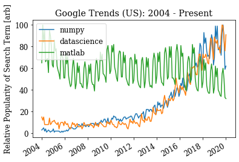

```python
fig, ax = plt.subplots()
for name, vals in data.items():
    plt.plot(vals['date'], vals['relpop'], label=name)
ax.set_title('Google Trends (US): 2004 - Present')
ax.set_ylabel('Relative Popularity of Search Term [arb]')
fig.autofmt_xdate()
ax.legend();
```

```python
def smooth(s, kernsize=21):
    s_padded = np.hstack((s[kernsize-1:0:-1], s, s[-2:-kernsize-1:-1]))
    kern = np.hamming(kernsize)
    res_padded = np.convolve(kern/kern.sum(), s_padded, mode='valid')
    # De-pad and renormalize
    return 100 * res_padded[kernsize//2:-kernsize//2+1] / res_padded.max()
```

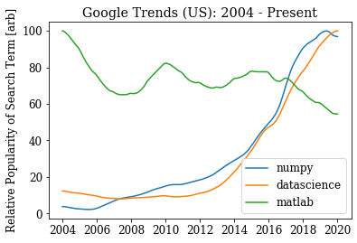

```python
fig, ax = plt.subplots()
for name, vals in data.items():
    plt.plot(vals['date'], smooth(vals['relpop']), label=name)
ax.set_title('Google Trends (US): 2004 - Present')
ax.set_ylabel('Relative Popularity of Search Term [arb]')
ax.legend();
```

# What's next for NumPy?

[figure not shown]

Image modified from [this PyData Amsterdam 2019 presentation](https://www.slideshare.net/RalfGommers/the-evolution-of-array-computing-in-python/14) by [Ralf Gommers](https://github.com/rgommers)

## Interoperability

Separate NumPy API from NumPy *execution engine*

- Allow other libraries ([Dask](https://dask.org/), [CuPy](https://cupy.chainer.org/), [PyTorch](https://pytorch.org/), etc.) to support NumPy API.
- Mitigate ecosystem fragmentation
  - E.g. don't want a re-implementation of `scipy` for each ML framework (`pytorch.scipy`, `tensorflow.scipy`, etc.)

### Current n-dimensional array landscape

[figure not shown]

Images from this [talk at PyData NY 2019](https://www.slideshare.net/RalfGommers/pydata-nyc-whatsnew-numpyscipy-2019?next_slideshow=1) by [Ralf Gommers](https://github.com/rgommers)

### Vision for the future

[figure not shown]

Images from this [talk at PyData NY 2019](https://www.slideshare.net/RalfGommers/pydata-nyc-whatsnew-numpyscipy-2019?next_slideshow=1) by [Ralf Gommers](https://github.com/rgommers)

## One approach: `__array_function__` protocol

- Proposed in [NEP 18](https://numpy.org/neps/nep-0018-array-function-protocol.html)
- Array function protocol enabled by default as of version 1.17

[figure not shown]

Image source: [this presentation](https://www.slideshare.net/RalfGommers/arrayfunction-conceptual-design-related-concepts?from_action=save) by [Ralf Gommers](https://github.com/rgommers)

### `__array_function__` example

```python
import numpy as np

rg = np.random.default_rng()
x = rg.random((5000, 1000))

# Factorize with np.linalg
q, r = np.linalg.qr(x)
type(q), type(r)
```

```
(numpy.ndarray, numpy.ndarray)
```

```python
import dask.array as da

d = da.from_array(x, chunks=(1000, 1000))

# Same call signature!
q, r = np.linalg.qr(d)
type(q), type(r)
```

```
(dask.array.core.Array, dask.array.core.Array)
```

## Lessons learned from `__array_function__`

- The `__array_function__` protocol has been successful, but has fallen short of universal adoption.
- Valuable feedback from the community has resulted in [NEP 37](https://numpy.org/neps/nep-0037-array-module.html)
  - Defines `__array_module__` protocol
  - Currently under development (interested?)

## The problem with data types...

Current `dtype` system has some flexibility issues

- Difficult to specify fully-featured types
- Some mechanisms (e.g. casting rules) are difficult to extend to new types

### Goal: Improve NumPy maintainability

- Improve organization of dtype checking/comparison machinery
- Use the same API for built-in and user-defined dtypes
- Improve extensibility of API: facilitate future additions/modifications

### User impact

- Easier-to-use mechanism for defining fully-feature dtypes (including from Python)
- Host of new dtypes for the ecosystem:
  - Physical units (cf. [astropy.unit](https://docs.astropy.org/en/stable/units/))
  - `bfloat16`, `int24`, etc.
  - Categorical types

An approach to overhauling the dtype system is [currently being fleshed out in a new NEP](https://github.com/numpy/numpy/blob/a111b551ae940d7d5f8523fef1cf3589c6ba00a0/doc/neps/nep-0033-extensible-dtypes.rst).

## Improved SIMD incorporation for `ufuncs`

Strike a balance between **optimization** and **maintainability**

- Define set of architecture-agnostic universal intrinsics
  - At build time, build code paths based on features available for the host architecture
  - At run time, detect which features are available and select which of available code paths to use
- In the process of being formalized in a [draft NEP](https://github.com/mattip/numpy/blob/nep_simd/doc/neps/nep-XXXX-SIMD-optimizations.rst)
  - Preliminary work in support of this proposed enhancement can be found [here](https://github.com/numpy/numpy/pull/13421/files) and [here](https://github.com/numpy/numpy/pull/13516)

**N.B.** this approach (i.e. using universal intrinsics) was adopted by OpenCV

## Supporting language features: type annotations

Thinking about how best to support type annotations became especially important when they became an official core language feature in Python 3.7.

This is currently the most cross-referenced issue in the NumPy GH repository:

```python
Markdown(filename="data/top_issues_table.md")
```

| Iss. # | xrefs | Issue |
| --- | --- | --- |
| 7370 | 22 | [Type hinting / annotation (PEP 484) for ndarray, dtype, and ufunc](https://github.com/numpy/numpy/issues/7370) |
| 5353 | 18 | [object array construction should require explicitly specifying dtype=object](https://github.com/numpy/numpy/issues/5353) |
| 11521 | 17 | [DEP: deprecate python code with DeprecationWarning (tracking issue)](https://github.com/numpy/numpy/issues/11521) |
| 11824 | 15 | [tcsh/csh resource file infecting f2py/distutils?](https://github.com/numpy/numpy/issues/11824) |
| 641 | 12 | [python3: regression for unique on dtype=object arrays with varying items types (Trac #2188)](https://github.com/numpy/numpy/issues/641) |

Work on type annotations is located in the numpy-stubs repository. Basic type annotations are supported:

```python
Code(filename="type_annotations.py")
```

```
import numpy as np

def my_strict_sin(x: np.ndarray) -> np.ndarray:
    return np.sin(x)

def my_chill_sin(x: np.array_like) -> np.array_like:
    return np.sin(x)

if __name__ == "__main__":
    a = np.arange(10)
    l = [1, 2, 3]
    my_strict_sin(a)     # Passes typecheck
    my_strict_sin(l)     # Fails typecheck
    my_chill_sin(a)      # Passes typecheck
    my_chill_sin(l)      # Passes typecheck
```

```python
!mypy type_annotations.py
```

```
type_annotations.py:13: error: Argument 1 to "my_strict_sin" has incompatible type "List[int]"; expected "ndarray"
Found 1 error in 1 file (checked 1 source file)
```

# ... and beyond: NumPy 2.0?

- Major revision -> opportunity for refactoring/enhancements that break API
  - Weigh potential for improvements against the pain of breaking changes
  - Commitment to stability still a central theme!
- So much new functionality being developed in external libraries
  - Changes that facilitate external development are priorities

A bit of the history surrounding the idea of NumPy 2.0 can be found [here](https://github.com/numpy/numpy/issues/9066)

# Getting involved

NumPy presents an opportunity to work on a project that is depended on by tens of millions of users (and counting). Here's how you can get involved:

1. Where discussion happens:
   - [Numpy discussion mailing list](https://www.scipy.org/scipylib/mailing-lists.html)
   - Numpy community meetings - video conference every-other-week: [Community calendar link](https://calendar.google.com/calendar?cid=YmVya2VsZXkuZWR1X2lla2dwaWdtMjMyamJobGRzZmIyYzJqODFjQGdyb3VwLmNhbGVuZGFyLmdvb2dsZS5jb20)
   - slack channel: numpy-team.slack.com
2. Contribute
   - [GitHub Issues](https://github.com/numpy/numpy/issues) and [open PRs](https://github.com/numpy/numpy/pulls) are a great entry point
     - If you want to get your hands dirty immediately, try starting with the [good first issue](https://github.com/numpy/numpy/issues?q=is%3Aopen+is%3Aissue+label%3A%22good+first+issue%22) label
     - For challenges with a greater scope, try the Enhancement or [Wish List](https://github.com/numpy/numpy/labels/23%20-%20Wish%20List) labels
   - Check out the discussion revolving around accepted and proposed [NEPs](https://numpy.org/neps/)

# Thank you!

If you have any questions, comments, or ideas please don't hesitate to contact me: rossbar@berkeley.edu

Also feel free to ask about/use/modify/contribute to this presentation on GitHub!

## Acknowledgements

> This project is funded in part by the Gordon and Betty Moore Foundation through [Grant GBMF5447](https://www.moore.org/grant-detail?grantId=GBMF5447f) and by the Alfred P. Sloan Foundation through [Grant G-2017-9960](https://sloan.org/grant-detail/8222) to the University of California, Berkeley.

And a special thanks to [@stefanv](https://github.com/stefanv), [@seberg](https://github.com/seberg), and [@mattip](https://github.com/mattip/) for their generous input in the creation of this presentation.